# week 13

Aurelia

16/01/2021

#1.Problem definition

Kira Plastinina is a Russian brand that is sold through a defunct chain of retail stores in Russia, Ukraine, Kazakhstan, Belarus, China, Philippines, and Armenia. The brand’s Sales and Marketing team would like to understand their customer’s behavior from data that they have collected over the past year. More specifically, they would like to learn the characteristics of customer groups

#2.Data sourcing

The dataset for this project can be found here

http://bit.ly/EcommerceCustomersDataset

1. The dataset consists of 10 numerical and 8 categorical attributes. The ‘Revenue’ attribute can be used as the class label.
2. “Administrative”, “Administrative Duration”, “Informational”, “Informational Duration”, “Product Related” and “Product Related Duration” represents the number of different types of pages visited by the visitor in that session and total time spent in each of these page categories. The values of these features are derived from the URL information of the pages visited by the user and updated in real-time when a user takes an action, e.g. moving from one page to another.
3. “Administrative”, “Administrative Duration”, “Informational”, “Informational Duration”, “Product Related” and “Product Related Duration” represents the number of different types of pages visited by the visitor in that session and total time spent in each of these page categories. The values of these features are derived from the URL information of the pages visited by the user and updated in real-time when a user takes an action, e.g. moving from one page to another.
4. The value of the “Bounce Rate” feature for a web page refers to the percentage of visitors who enter the site from that page and then leave (“bounce”) without triggering any other requests to the analytics server during that session. 5.The value of the “Exit Rate” feature for a specific web page is calculated as for all pageviews to the page, the percentage that was the last in the session. 6.The “Page Value” feature represents the average value for a web page that a user visited before completing an e-commerce transaction. 7.The “Special Day” feature indicates the closeness of the site visiting time to a specific special day (e.g. Mother’s Day, Valentine’s Day) in which the sessions are more likely to be finalized with the transaction. The value of this attribute is determined by considering the dynamics of e-commerce such as the duration between the order date and delivery date. For example, for Valentina’s day, this value takes a nonzero value between February 2 and February 12, zero before and after this date unless it is close to another special day, and its maximum value of 1 on February 8. 8.The dataset also includes the operating system, browser, region, traffic type, visitor type as returning or new visitor, a Boolean value indicating whether the date of the visit is weekend, and month of the year.

#3.Check the data

## 3.1 installing packages and loading libraries

```r
install.packages("DataExplorer")
install.packages("Hmisc")
install.packages("pastecs")
install.packages("psych")
```

```r
install.packages("corrplot")
install.packages("factoextra")
install.packages("Rtsne")
install.packages("caret")
install.packages("tidyverse")
install.packages("rlang",dependencies = TRUE)
```

```
##
##   There is a binary version available but the source version is later:
##       binary source needs_compilation
## rlang  0.4.6  0.4.7              TRUE
##
##   Binaries will be installed
```

```
##
##  C:\Users\HP 15\AppData\Local\Temp\Rtmpsv3NM8\downloaded_packages
```

```r
install.packages("tidyverse")
library(tidyverse)
library(magrittr)
```

```r
library(warn = -1)


library(RColorBrewer)
library(ggplot2)
library(lattice)
library(corrplot)
library(DataExplorer)
library(Hmisc)
library(pastecs)
library(psych)
library(factoextra)
library(Rtsne)
library(caret)
```

## 3.2 loading and previweing dataset

```r
# loading the dataset

df = read_csv('http://bit.ly/EcommerceCustomersDataset')
# Checking the top observations

head(df)
```

```
## # A tibble: 6 x 18
##   Administrative Administrative_~ Informational Informational_D~ ProductRelated
##            <dbl>            <dbl>         <dbl>            <dbl>          <dbl>
## 1              0                0             0                0              1
## 2              0                0             0                0              2
## 3              0               -1             0               -1              1
## 4              0                0             0                0              2
## 5              0                0             0                0             10
## 6              0                0             0                0             19
## # ... with 13 more variables: ProductRelated_Duration <dbl>, BounceRates <dbl>,
## #   ExitRates <dbl>, PageValues <dbl>, SpecialDay <dbl>, Month <chr>,
## #   OperatingSystems <dbl>, Browser <dbl>, Region <dbl>, TrafficType <dbl>,
## #   VisitorType <chr>, Weekend <lgl>, Revenue <lgl>
```

```r
# Checking the bottom observations

tail(df)
```

```
## # A tibble: 6 x 18
##   Administrative Administrative_~ Informational Informational_D~ ProductRelated
##            <dbl>            <dbl>         <dbl>            <dbl>          <dbl>
## 1              0                0             1                0             16
## 2              3              145             0                0             53
## 3              0                0             0                0              5
## 4              0                0             0                0              6
## 5              4               75             0                0             15
## 6              0                0             0                0              3
## # ... with 13 more variables: ProductRelated_Duration <dbl>, BounceRates <dbl>,
## #   ExitRates <dbl>, PageValues <dbl>, SpecialDay <dbl>, Month <chr>,
## #   OperatingSystems <dbl>, Browser <dbl>, Region <dbl>, TrafficType <dbl>,
## #   VisitorType <chr>, Weekend <lgl>, Revenue <lgl>
```

```r
# Viewing the structure of the dataset
# ---
#
str(df)
```

```
## tibble [12,330 x 18] (S3: spec_tbl_df/tbl_df/tbl/data.frame)
##  $ Administrative         : num [1:12330] 0 0 0 0 0 0 0 1 0 0 ...
##  $ Administrative_Duration: num [1:12330] 0 0 -1 0 0 0 -1 -1 0 0 ...
##  $ Informational          : num [1:12330] 0 0 0 0 0 0 0 0 0 0 ...
##  $ Informational_Duration : num [1:12330] 0 0 -1 0 0 0 -1 -1 0 0 ...
##  $ ProductRelated         : num [1:12330] 1 2 1 2 10 19 1 1 2 3 ...
##  $ ProductRelated_Duration: num [1:12330] 0 64 -1 2.67 627.5 ...
##  $ BounceRates            : num [1:12330] 0.2 0 0.2 0.05 0.02 ...
##  $ ExitRates              : num [1:12330] 0.2 0.1 0.2 0.14 0.05 ...
##  $ PageValues             : num [1:12330] 0 0 0 0 0 0 0 0 0 0 ...
##  $ SpecialDay             : num [1:12330] 0 0 0 0 0 0 0.4 0 0.8 0.4 ...
##  $ Month                  : chr [1:12330] "Feb" "Feb" "Feb" "Feb" ...
##  $ OperatingSystems       : num [1:12330] 1 2 4 3 3 2 2 1 2 2 ...
##  $ Browser                : num [1:12330] 1 2 1 2 3 2 4 2 2 4 ...
##  $ Region                 : num [1:12330] 1 1 9 2 1 1 3 1 2 1 ...
##  $ TrafficType            : num [1:12330] 1 2 3 4 4 3 3 5 3 2 ...
##  $ VisitorType            : chr [1:12330] "Returning_Visitor" "Returning_Visitor" "Returning_Visitor" "Returning_Visitor" ...
##  $ Weekend                : logi [1:12330] FALSE FALSE FALSE FALSE TRUE FALSE ...
##  $ Revenue                : logi [1:12330] FALSE FALSE FALSE FALSE FALSE FALSE ...
##  - attr(*, "spec")=
##   .. cols(
##   ..   Administrative = col_double(),
##   ..   Administrative_Duration = col_double(),
##   ..   Informational = col_double(),
##   ..   Informational_Duration = col_double(),
##   ..   ProductRelated = col_double(),
##   ..   ProductRelated_Duration = col_double(),
##   ..   BounceRates = col_double(),
##   ..   ExitRates = col_double(),
##   ..   PageValues = col_double(),
##   ..   SpecialDay = col_double(),
##   ..   Month = col_character(),
##   ..   OperatingSystems = col_double(),
##   ..   Browser = col_double(),
##   ..   Region = col_double(),
##   ..   TrafficType = col_double(),
##   ..   VisitorType = col_character(),
##   ..   Weekend = col_logical(),
##   ..   Revenue = col_logical()
##   .. )
```

```r
# Viewing the statistical summary of the dataset
# ---
#
summary(df)
```

```
##  Administrative   Administrative_Duration Informational
##  Min.   : 0.000   Min.   :  -1.00         Min.   : 0.000
##  1st Qu.: 0.000   1st Qu.:   0.00         1st Qu.: 0.000
##  Median : 1.000   Median :   8.00         Median : 0.000
##  Mean   : 2.318   Mean   :  80.91         Mean   : 0.504
##  3rd Qu.: 4.000   3rd Qu.:  93.50         3rd Qu.: 0.000
##  Max.   :27.000   Max.   :3398.75         Max.   :24.000
##  NA's   :14       NA's   :14              NA's   :14
##  Informational_Duration ProductRelated   ProductRelated_Duration
##  Min.   :  -1.00        Min.   :  0.00   Min.   :   -1.0
##  1st Qu.:   0.00        1st Qu.:  7.00   1st Qu.:  185.0
##  Median :   0.00        Median : 18.00   Median :  599.8
##  Mean   :  34.51        Mean   : 31.76   Mean   : 1196.0
##  3rd Qu.:   0.00        3rd Qu.: 38.00   3rd Qu.: 1466.5
##  Max.   :2549.38        Max.   :705.00   Max.   :63973.5
##  NA's   :14             NA's   :14       NA's   :14
##   BounceRates         ExitRates         PageValues        SpecialDay
##  Min.   :0.000000   Min.   :0.00000   Min.   :  0.000   Min.   :0.00000
##  1st Qu.:0.000000   1st Qu.:0.01429   1st Qu.:  0.000   1st Qu.:0.00000
##  Median :0.003119   Median :0.02512   Median :  0.000   Median :0.00000
##  Mean   :0.022152   Mean   :0.04300   Mean   :  5.889   Mean   :0.06143
##  3rd Qu.:0.016684   3rd Qu.:0.05000   3rd Qu.:  0.000   3rd Qu.:0.00000
##  Max.   :0.200000   Max.   :0.20000   Max.   :361.764   Max.   :1.00000
##  NA's   :14         NA's   :14
##     Month           OperatingSystems    Browser           Region
##  Length:12330       Min.   :1.000    Min.   : 1.000   Min.   :1.000
##  Class :character   1st Qu.:2.000    1st Qu.: 2.000   1st Qu.:1.000
##  Mode  :character   Median :2.000    Median : 2.000   Median :3.000
##                     Mean   :2.124    Mean   : 2.357   Mean   :3.147
##                     3rd Qu.:3.000    3rd Qu.: 2.000   3rd Qu.:4.000
##                     Max.   :8.000    Max.   :13.000   Max.   :9.000
##
##   TrafficType    VisitorType         Weekend         Revenue
##  Min.   : 1.00   Length:12330       Mode :logical   Mode :logical
##  1st Qu.: 2.00   Class :character   FALSE:9462      FALSE:10422
##  Median : 2.00   Mode  :character   TRUE :2868      TRUE :1908
##  Mean   : 4.07
##  3rd Qu.: 4.00
##  Max.   :20.00
##
```

```r
# Viewing the dimension of  dataset
dim(df)
```

```
## [1] 12330    18
```

The dataset has 18columns and 12330 rows

#4.Performing data cleaning

##4.1 Duplicates

```r
duplicated_rows <- df[duplicated(df),]
duplicated_rows
```

```
## # A tibble: 119 x 18
##    Administrative Administrative_~ Informational Informational_D~ ProductRelated
##             <dbl>            <dbl>         <dbl>            <dbl>          <dbl>
##  1              0                0             0                0              1
##  2              0                0             0                0              1
##  3              0                0             0                0              1
##  4              0                0             0                0              1
##  5              0                0             0                0              1
##  6              0                0             0                0              1
##  7              0                0             0                0              1
##  8              0                0             0                0              1
##  9              0                0             0                0              2
## 10              0                0             0                0              1
## # ... with 109 more rows, and 13 more variables: ProductRelated_Duration <dbl>,
## #   BounceRates <dbl>, ExitRates <dbl>, PageValues <dbl>, SpecialDay <dbl>,
## #   Month <chr>, OperatingSystems <dbl>, Browser <dbl>, Region <dbl>,
## #   TrafficType <dbl>, VisitorType <chr>, Weekend <lgl>, Revenue <lgl>
```

There are 119 duplicates

```r
# Removing duplicates

df <- df[!duplicated(df),]
```

```r
# verifying duplicates  have been dropped by checking the new dimension of the dataset

dim(df)
```

```
## [1] 12211    18
```

New number of rows is 12211,initially before duplicates weredropped the number of rows was 12330

##4.2 Missing data

```r
# Checking for Missing Values per column

colSums(is.na(df))
```

```
##          Administrative Administrative_Duration           Informational
##                      12                      12                      12
##  Informational_Duration          ProductRelated ProductRelated_Duration
##                      12                      12                      12
##             BounceRates               ExitRates              PageValues
##                      12                      12                       0
##              SpecialDay                   Month        OperatingSystems
##                       0                       0                       0
##                 Browser                  Region             TrafficType
##                       0                       0                       0
##             VisitorType                 Weekend                 Revenue
##                       0                       0                       0
```

```r
# Checking for missing for the whole dataset
sum(is.na(df))
```

```
## [1] 96
```

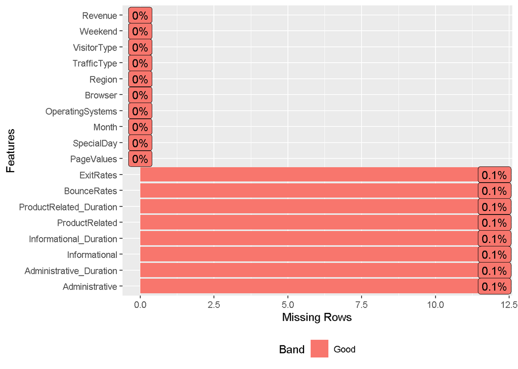

```r
# different ways of visualizing missing data

plot_missing(df)
```

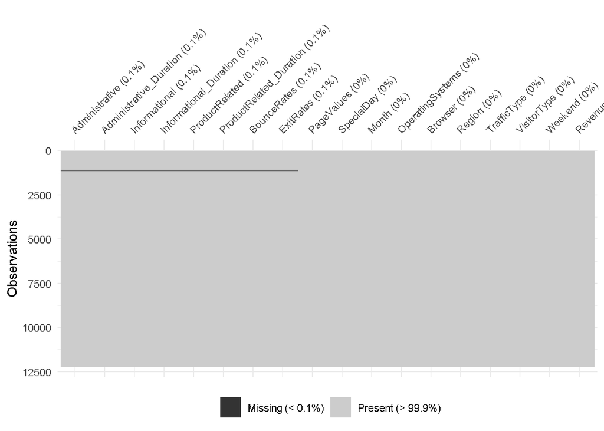

```r
install.packages("naniar")
library(naniar)

vis_miss(df)
```

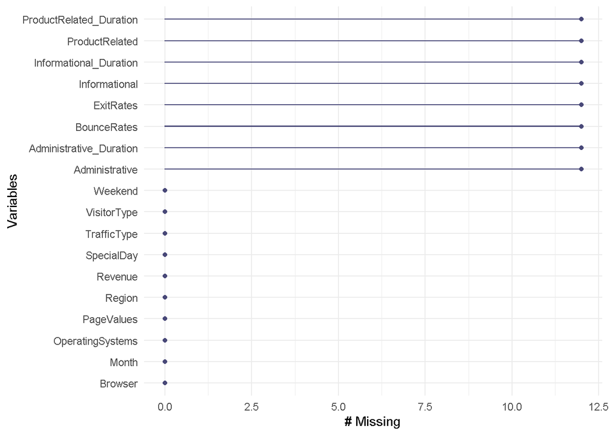

```r
gg_miss_var(df)
```

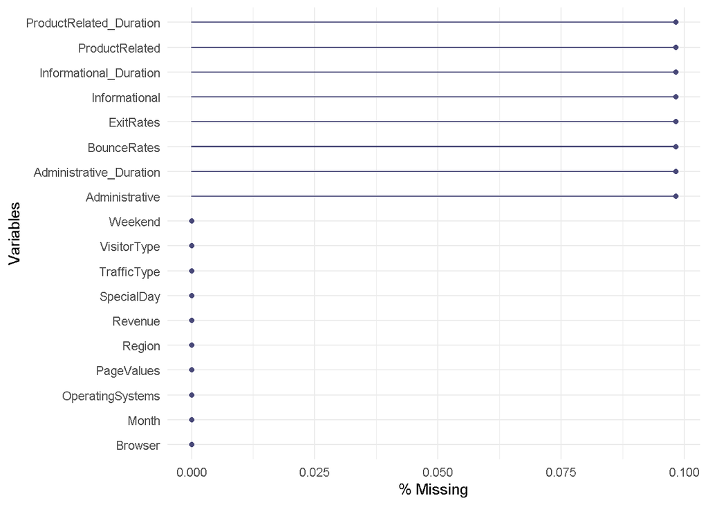

```r
gg_miss_var(df, show_pct = TRUE)
```

```r
# Dropping missing values dfclean= na.omit(df)
dfclean<-na.omit(df)
```

```r
#Confriming that the missing values have been deleted.
sum(is.na(dfclean))
```

```
## [1] 0
```

there are now no missing values

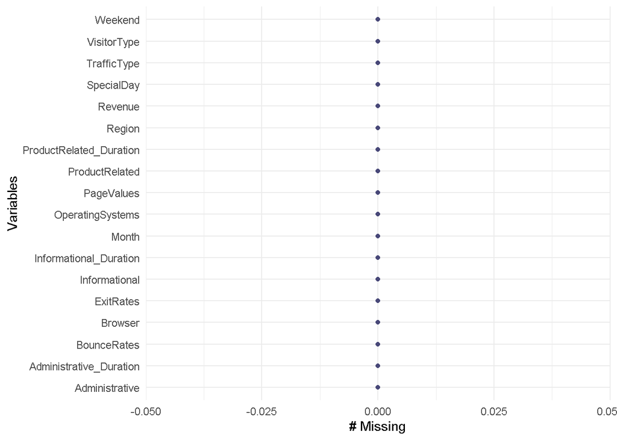

```r
#plotting cleaned dataset dfcleaned
gg_miss_var(dfclean)
```

## 4.3 Outliers

```r
str(dfclean)
```

```
## tibble [12,199 x 18] (S3: tbl_df/tbl/data.frame)
##  $ Administrative         : num [1:12199] 0 0 0 0 0 0 0 1 0 0 ...
##  $ Administrative_Duration: num [1:12199] 0 0 -1 0 0 0 -1 -1 0 0 ...
##  $ Informational          : num [1:12199] 0 0 0 0 0 0 0 0 0 0 ...
##  $ Informational_Duration : num [1:12199] 0 0 -1 0 0 0 -1 -1 0 0 ...
##  $ ProductRelated         : num [1:12199] 1 2 1 2 10 19 1 1 2 3 ...
##  $ ProductRelated_Duration: num [1:12199] 0 64 -1 2.67 627.5 ...
##  $ BounceRates            : num [1:12199] 0.2 0 0.2 0.05 0.02 ...
##  $ ExitRates              : num [1:12199] 0.2 0.1 0.2 0.14 0.05 ...
##  $ PageValues             : num [1:12199] 0 0 0 0 0 0 0 0 0 0 ...
##  $ SpecialDay             : num [1:12199] 0 0 0 0 0 0 0.4 0 0.8 0.4 ...
##  $ Month                  : chr [1:12199] "Feb" "Feb" "Feb" "Feb" ...
##  $ OperatingSystems       : num [1:12199] 1 2 4 3 3 2 2 1 2 2 ...
##  $ Browser                : num [1:12199] 1 2 1 2 3 2 4 2 2 4 ...
##  $ Region                 : num [1:12199] 1 1 9 2 1 1 3 1 2 1 ...
##  $ TrafficType            : num [1:12199] 1 2 3 4 4 3 3 5 3 2 ...
##  $ VisitorType            : chr [1:12199] "Returning_Visitor" "Returning_Visitor" "Returning_Visitor" "Returning_Visitor" ...
##  $ Weekend                : logi [1:12199] FALSE FALSE FALSE FALSE TRUE FALSE ...
##  $ Revenue                : logi [1:12199] FALSE FALSE FALSE FALSE FALSE FALSE ...
##  - attr(*, "na.action")= 'omit' Named int [1:12] 1050 1116 1117 1118 1119 1443 1444 1445 1446 1996 ...
##   ..- attr(*, "names")= chr [1:12] "1050" "1116" "1117" "1118" ...
```

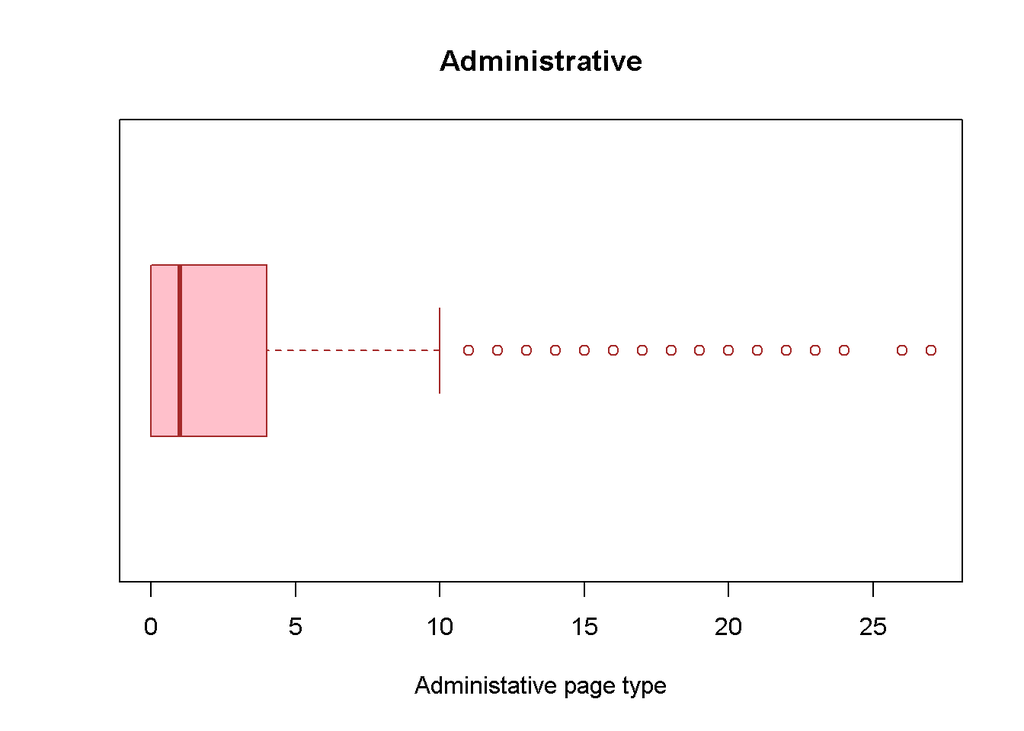

```r
boxplot(dfclean$Administrative,col = "pink",main = "Administrative",border = "brown",xlab="Administative page type",horizontal = T)
```

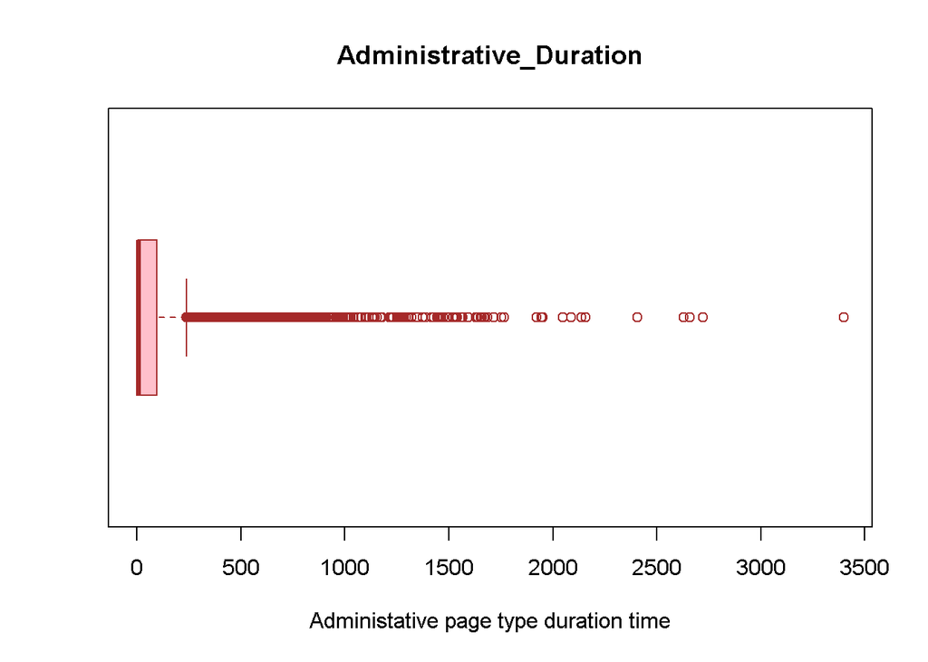

```r
boxplot(dfclean$Administrative_Duration,col = "pink",main = "Administrative_Duration",border = "brown",xlab="Administative page type duration time",horizontal = T)
```

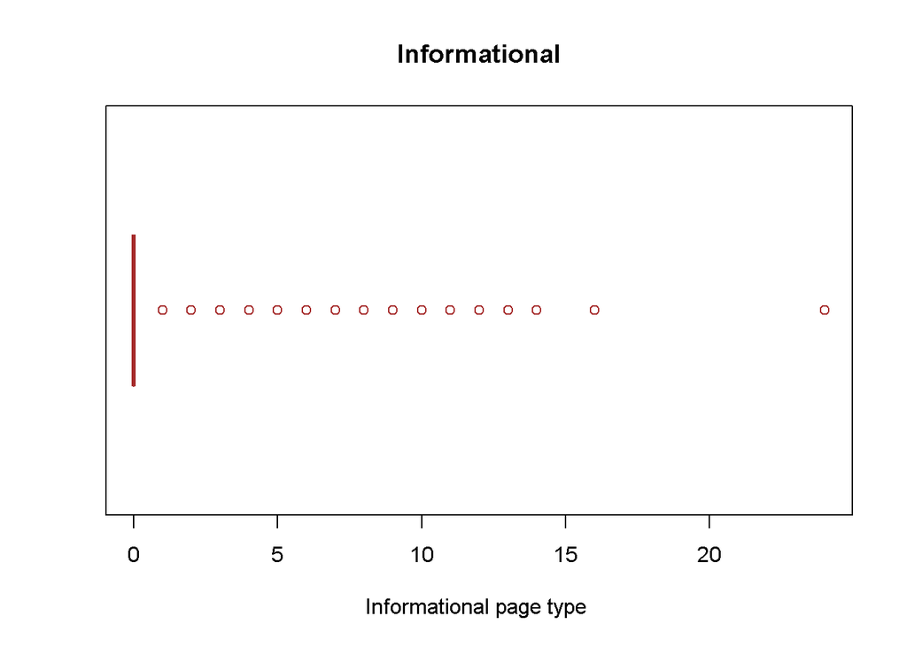

```r
 boxplot(dfclean$Informational,col = "pink",main = "Informational",border = "brown",xlab="Informational page type ",horizontal = T)
```

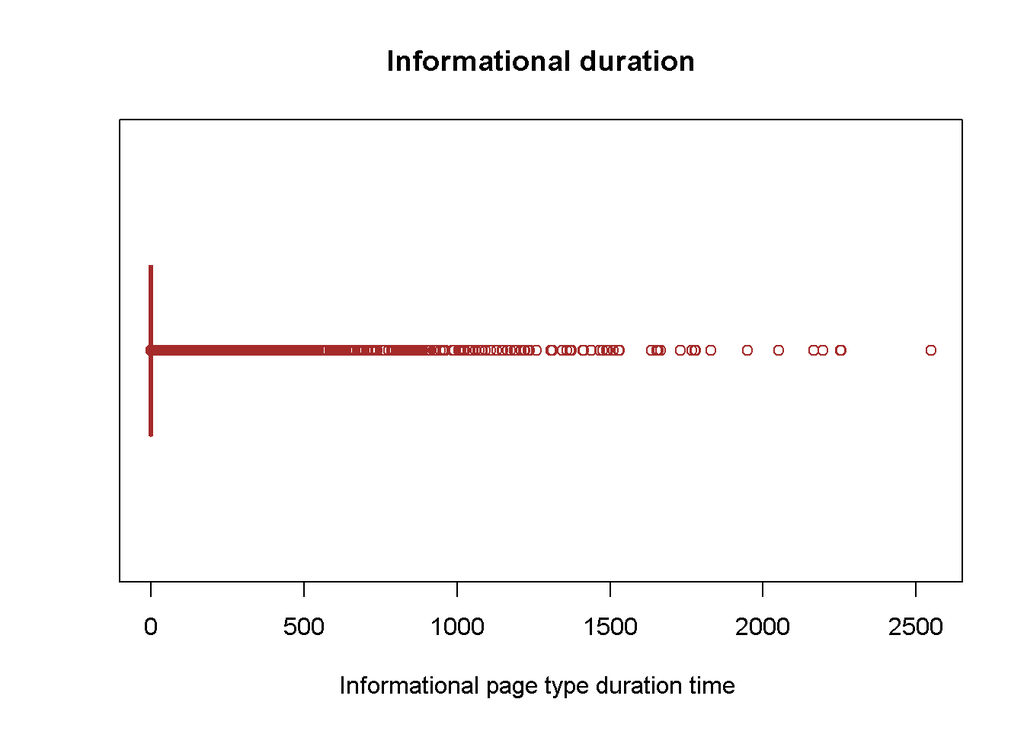

```r
 boxplot(dfclean$Informational_Duration,col = "pink",main = "Informational duration",border = "brown",xlab="Informational page type duration time ",horizontal = T)
```

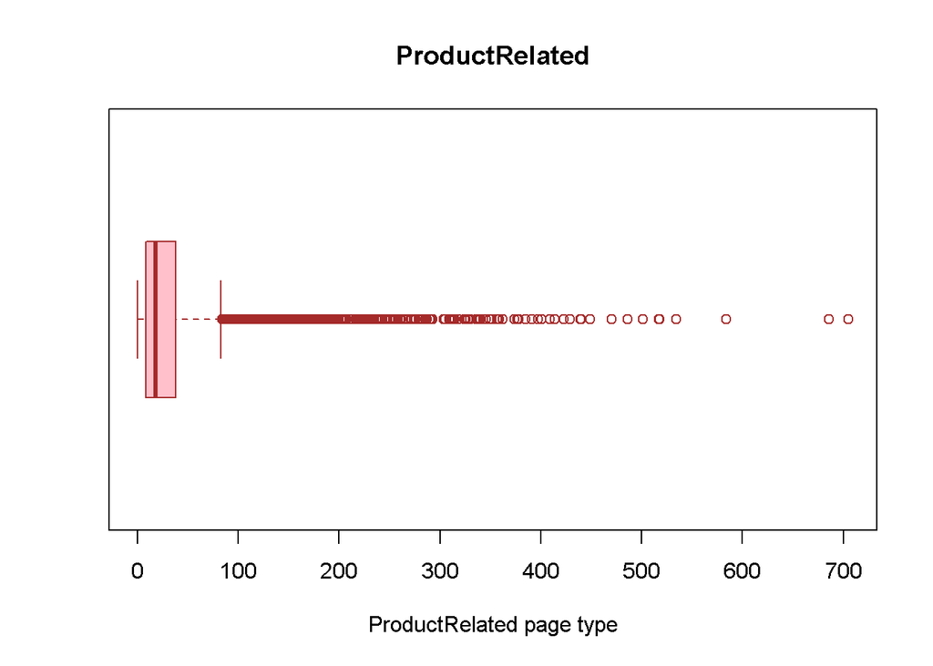

```r
boxplot(dfclean$ProductRelated,col = "pink",main = "ProductRelated",border = "brown",xlab="ProductRelated page type",horizontal = T)
```

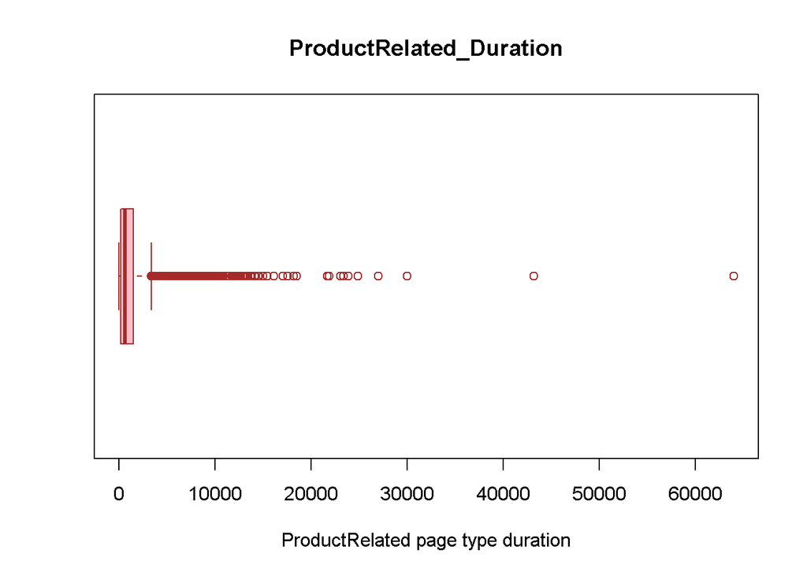

```r
boxplot(dfclean$ProductRelated_Duration,col = "pink",main = "ProductRelated_Duration",border = "brown",xlab="ProductRelated page type duration",horizontal = T)
```

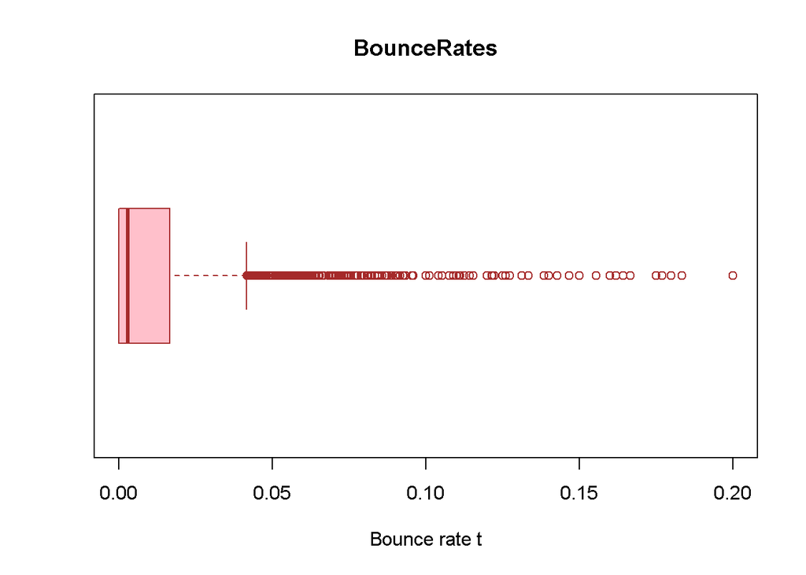

```r
boxplot(dfclean$BounceRates,col = "pink",main = "BounceRates",border = "brown",xlab="Bounce rate t",horizontal = T)
```

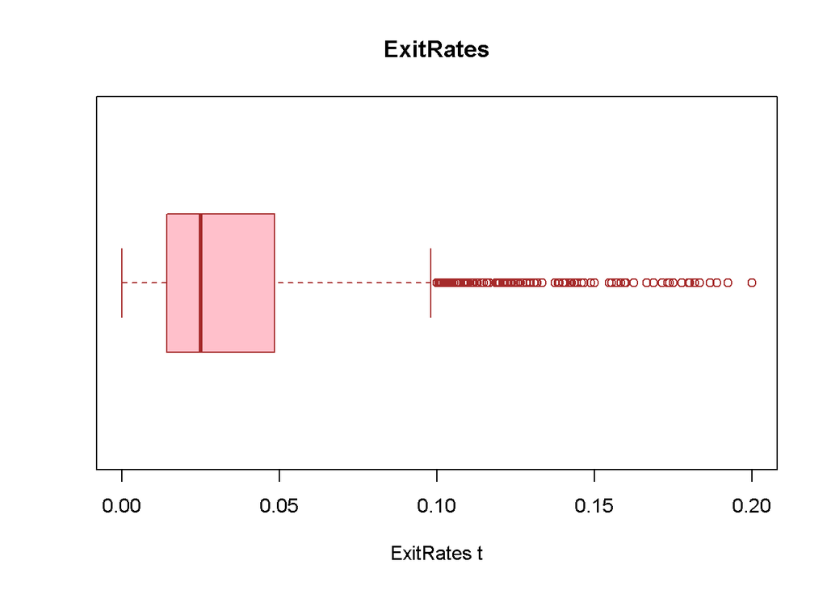

```r
boxplot(dfclean$ExitRates,col = "pink",main = "ExitRates",border = "brown",xlab="ExitRates t",horizontal = T)
```

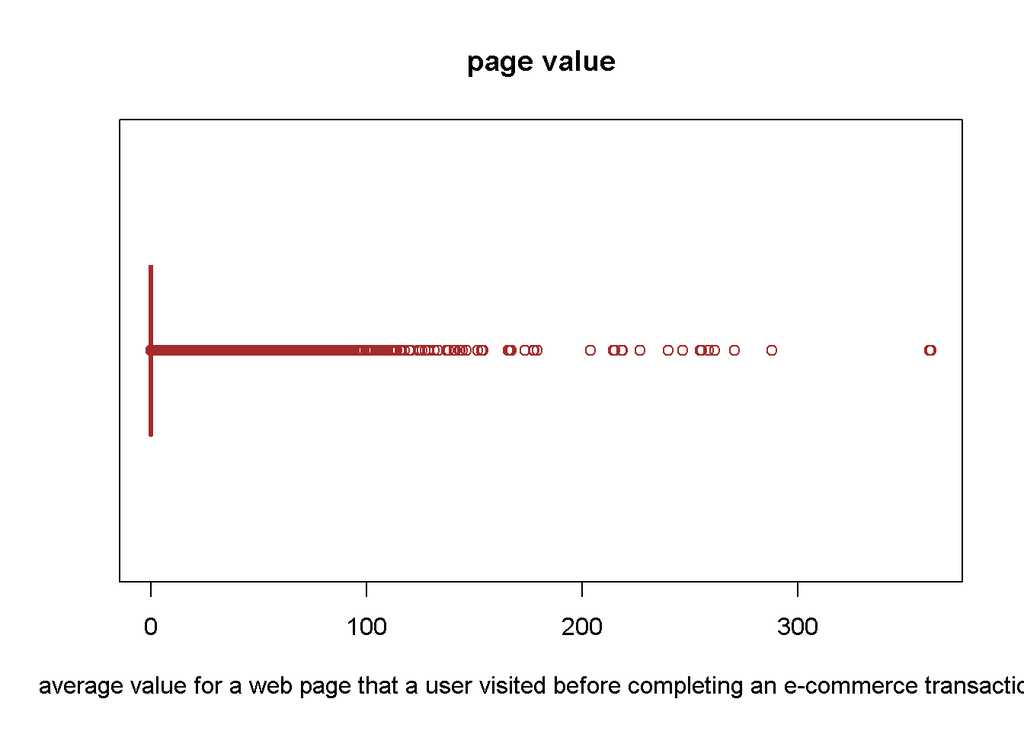

```r
boxplot(dfclean$PageValues,col = "pink",main = "page value",border = "brown",xlab="average value for a web page that a user visited before completing an e-commerce transaction",horizontal = T)
```

There are outliers noted but they wont be removed at this point in time ,more insights could be drawn from them later

#5.EDA

##5.1 Univariate

```r
# Checking numeric columns

dfcleaned_num<-select_if(dfclean, is.numeric)
dfcleaned_num
```

```
## # A tibble: 12,199 x 14
##    Administrative Administrative_~ Informational Informational_D~ ProductRelated
##             <dbl>            <dbl>         <dbl>            <dbl>          <dbl>
##  1              0                0             0                0              1
##  2              0                0             0                0              2
##  3              0               -1             0               -1              1
##  4              0                0             0                0              2
##  5              0                0             0                0             10
##  6              0                0             0                0             19
##  7              0               -1             0               -1              1
##  8              1               -1             0               -1              1
##  9              0                0             0                0              2
## 10              0                0             0                0              3
## # ... with 12,189 more rows, and 9 more variables:
## #   ProductRelated_Duration <dbl>, BounceRates <dbl>, ExitRates <dbl>,
## #   PageValues <dbl>, SpecialDay <dbl>, OperatingSystems <dbl>, Browser <dbl>,
## #   Region <dbl>, TrafficType <dbl>
```

```r
dfcleaned_num <- data.frame(
  Min = apply(dfclean, 2, min),    # minimum
  Med = apply(dfclean, 2, median), # median
  Mean = apply(dfclean, 2, mean),  # mean
  SD = apply(dfclean, 2, sd),      # Standard deviation
  Max = apply(dfclean, 2, max)     # Maximum
)
```

[output not shown]

```r
head(dfcleaned_num)
```

```
##                                  Min          Med Mean          SD          Max
## Administrative                     0            1   NA    3.330851           27
## Administrative_Duration    -1.000000     9.000000   NA  177.528168  3398.750000
## Informational                      0            0   NA    1.275817           24
## Informational_Duration     -1.000000     0.000000   NA  141.458499  2549.375000
## ProductRelated                     0           18   NA   44.600911          705
## ProductRelated_Duration    -1.000000   609.541667   NA 1919.927472 63973.522230
```

```r
mean(dfclean$Administrative)
```

```
## [1] 2.340028
```

```r
median(dfclean$Administrative)
```

```
## [1] 1
```

```r
sd(dfclean$Administrative)
```

```
## [1] 3.330851
```

```r
var(dfclean$Administrative)
```

```
## [1] 11.09457
```

```r
range(dfclean$Administrative)
```

```
## [1]  0 27
```

```r
install.packages("moments")
library(moments)
skewness(dfclean$Administrative)
```

```
## [1] 1.946248
```

```r
kurtosis(dfclean$Administrative)
```

```
## [1] 7.636106
```

The administrative column is skewed to the right It has a skewness of 1.946248 which means that the data is positively skewed. The kurtosis of the variable is 7.636106. This means that the data is not flat but it is peaky.

```r
min(dfclean$BounceRates)
```

```
## [1] 0
```

```r
max(dfclean$BounceRates)
```

```
## [1] 0.2
```

```r
mean(dfclean$BounceRates)
```

```
## [1] 0.02044674
```

```r
median(dfclean$BounceRates)
```

```
## [1] 0.002930403
```

```r
sd(dfclean$BounceRates)
```

```
## [1] 0.0454025
```

```r
var(dfclean$BounceRates)
```

```
## [1] 0.002061387
```

```r
range(dfclean$BounceRates)
```

```
## [1] 0.0 0.2
```

```r
skewness(dfclean$BounceRates)
```

```
## [1] 3.152874
```

```r
kurtosis(dfclean$BounceRates)
```

```
## [1] 12.25506
```

```r
min(dfclean$ExitRates)
```

```
## [1] 0
```

```r
max(dfclean$ExitRates)
```

```
## [1] 0.2
```

```r
mean(dfclean$ExitRates)
```

```
## [1] 0.04149678
```

```r
median(dfclean$ExitRates)
```

```
## [1] 0.025
```

```r
sd(dfclean$ExitRates)
```

```
## [1] 0.04624716
```

```r
var(dfclean$ExitRates)
```

```
## [1] 0.0021388
```

```r
range(dfclean$ExitRates)
```

```
## [1] 0.0 0.2
```

```r
skewness(dfclean$ExitRates)
```

```
## [1] 2.233125
```

```r
kurtosis(dfclean$ExitRates)
```

```
## [1] 7.624252
```

```r
min(dfclean$PageValues)
```

```
## [1] 0
```

```r
max(dfclean$PageValues)
```

```
## [1] 361.7637
```

```r
mean(dfclean$PageValues)
```

```
## [1] 5.9525
```

```r
median(dfclean$PageValues)
```

```
## [1] 0
```

```r
sd(dfclean$PageValues)
```

```
## [1] 18.65779
```

```r
var(dfclean$PageValues)
```

```
## [1] 348.1132
```

```r
range(dfclean$PageValues)
```

```
## [1]   0.0000 361.7637
```

```r
skewness(dfclean$PageValues)
```

```
## [1] 6.348663
```

```r
kurtosis(dfclean$PageValues)
```

```
## [1] 67.94031
```

```r
min(dfclean$SpecialDay)
```

```
## [1] 0
```

```r
max(dfclean$SpecialDay)
```

```
## [1] 1
```

```r
mean(dfclean$SpecialDay)
```

```
## [1] 0.06197229
```

```r
median(dfclean$SpecialDay)
```

```
## [1] 0
```

```r
sd(dfclean$SpecialDay)
```

```
## [1] 0.1997106
```

```r
var(dfclean$SpecialDay)
```

```
## [1] 0.03988432
```

```r
range(dfclean$SpecialDay)
```

```
## [1] 0 1
```

```r
skewness(dfclean$SpecialDay)
```

```
## [1] 3.284481
```

```r
kurtosis(dfclean$SpecialDay)
```

```
## [1] 12.78605
```

```r
getmode <- function(v) {
   uniqv <- unique(v)
   uniqv[which.max(tabulate(match(v, uniqv)))]
}

# Calculating the mode using out getmode() function
# ---
#
modeadm <- getmode(dfclean$Administrative)
modespecialday <- getmode(dfclean$SpecialDay)
modeadmduration <- getmode(dfclean$Administrative_Duration)
modeinfor <- getmode(dfclean$Informational)
modeinfodura<- getmode(dfclean$Informational_Duration)
modeproductrel <- getmode(dfclean$ProductRelated)
modeproductreladuration <- getmode(dfclean$ProductRelated_Duration)
modebouncerate <- getmode(dfclean$BounceRates)
modeexitrate <- getmode(dfclean$ExitRates)
modepagevalues <- getmode(dfclean$PageValues)
# Then printing out modes of the various variables
modeadm
```

```
## [1] 0
```

```r
modespecialday
```

```
## [1] 0
```

```r
modeadmduration
```

```
## [1] 0
```

```r
modeinfor
```

```
## [1] 0
```

```r
modeinfodura
```

```
## [1] 0
```

```r
modeproductrel
```

```
## [1] 1
```

```r
modeproductreladuration
```

```
## [1] 0
```

```r
modebouncerate
```

```
## [1] 0
```

```r
modeexitrate
```

```
## [1] 0.2
```

```r
modepagevalues
```

```
## [1] 0
```

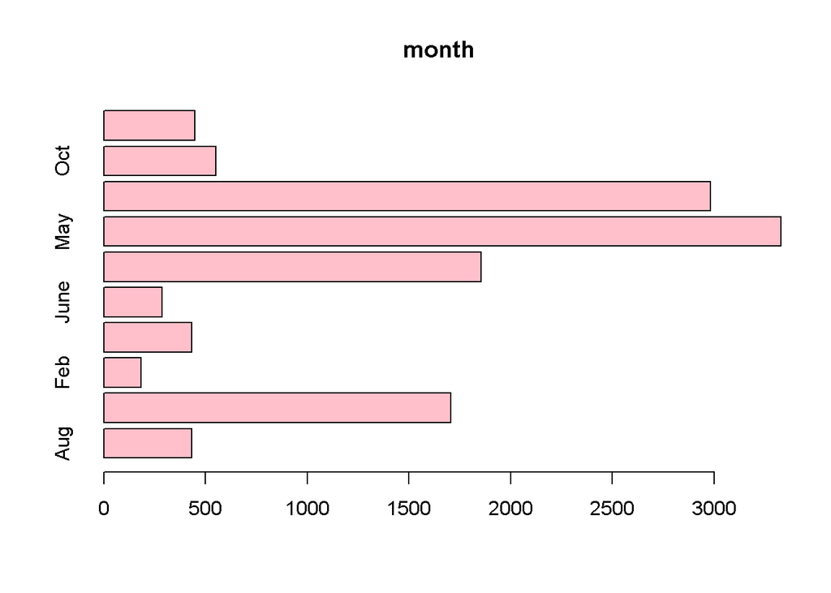

```r
# Bar plots
counts <- table(dfclean$Month)
barplot(counts, main="month", horiz=TRUE,col="pink")
```

May is the month with the highest number of visitors while Feb has the list

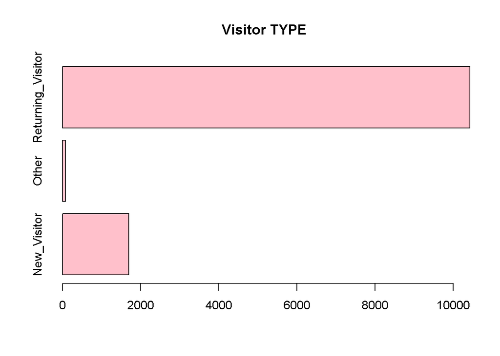

```r
counts <- table(dfclean$VisitorType)
barplot(counts, main="Visitor TYPE", horiz=TRUE,col="pink")
```

Returning visitors were the highest type of visitors

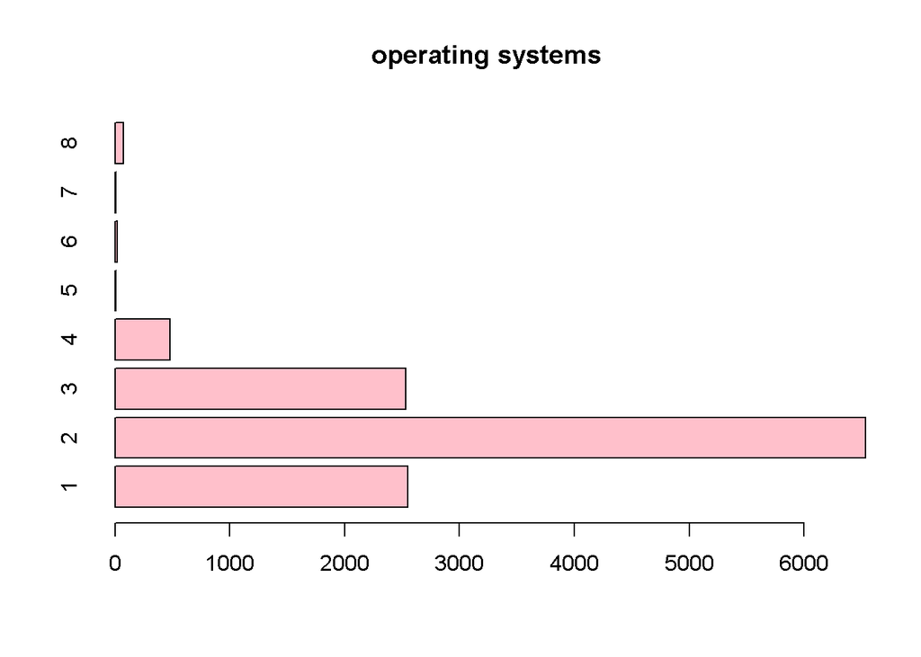

```r
counts <- table(dfclean$OperatingSystems)
barplot(counts, main="operating systems", horiz=TRUE,col="pink")
```

The most used operating system was type 2 and the least favourable was 5 and7

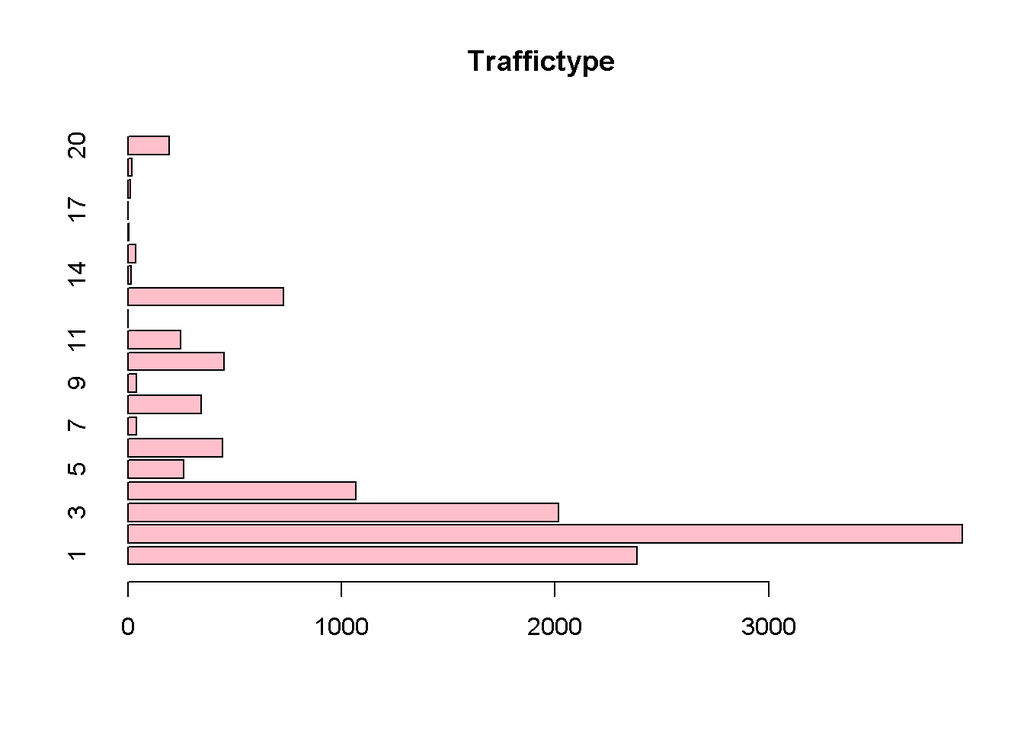

```r
counts <- table(dfclean$TrafficType)
barplot(counts, main="Traffictype", horiz=TRUE,col="pink")
```

The most frequent traffictype were 2,1 and 3 respectivelu

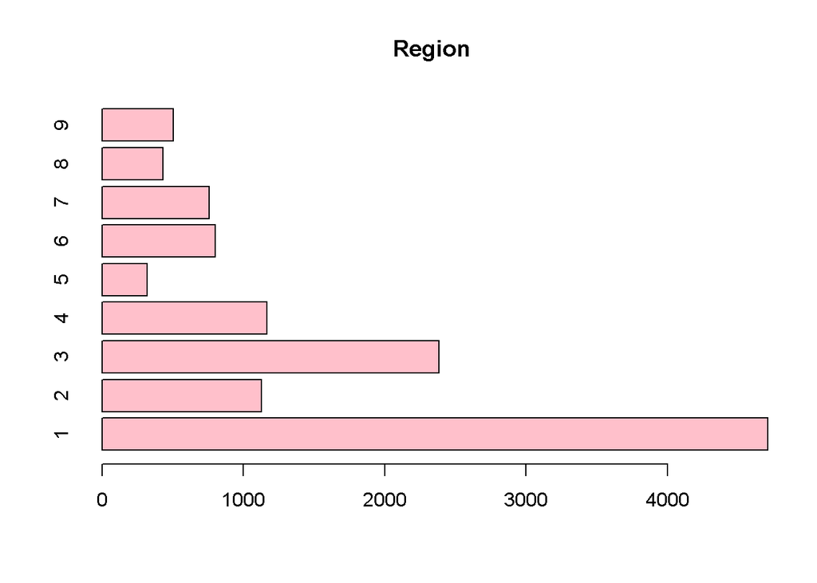

```r
counts <- table(dfclean$Region)
barplot(counts, main="Region", horiz=TRUE,col="pink")
```

Region number 1 had the most activity, region 5 was least active.

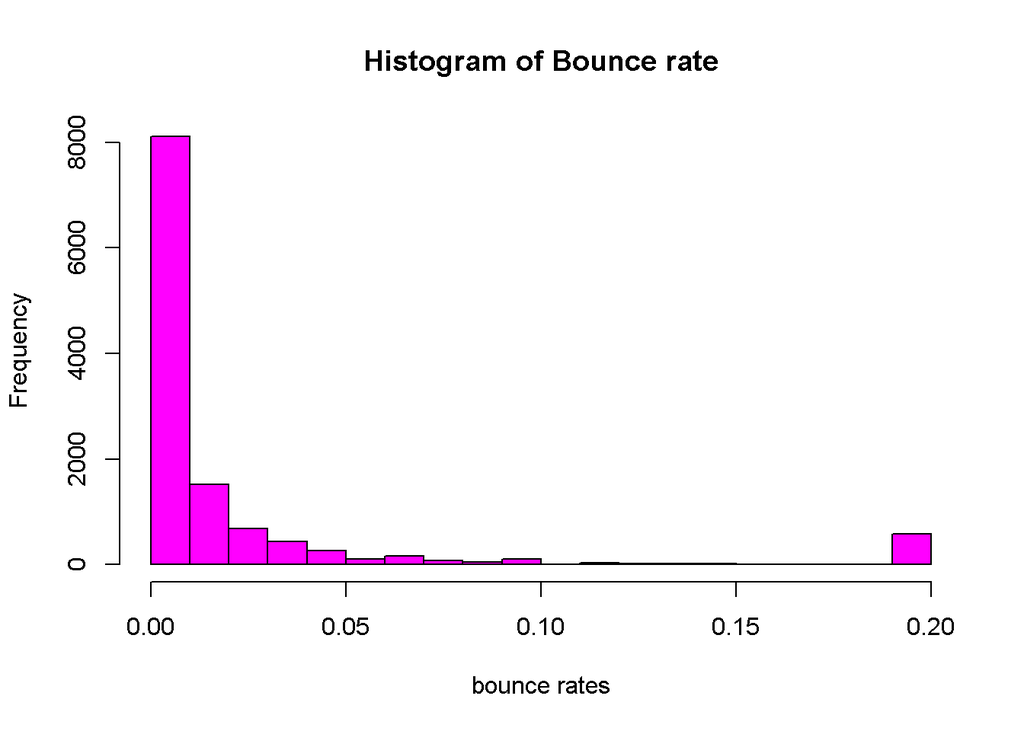

```r
hist(dfclean$BounceRates,
     main = "Histogram of Bounce rate",
     xlab = "bounce rates", col = "magenta")
```

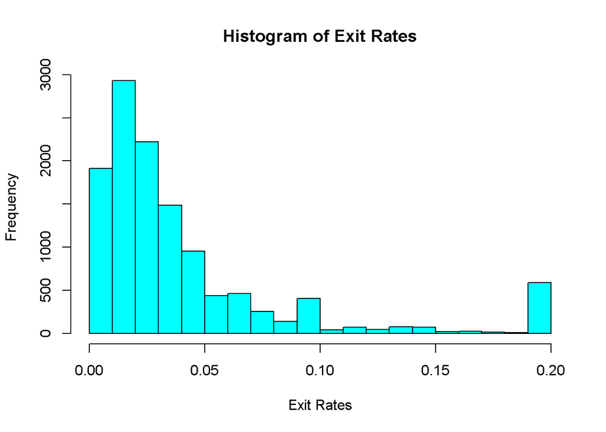

```r
hist(df$ExitRates,
     main = "Histogram of Exit Rates",
     xlab = "Exit Rates",
     col = "cyan")
```

##5.2 Bivariate

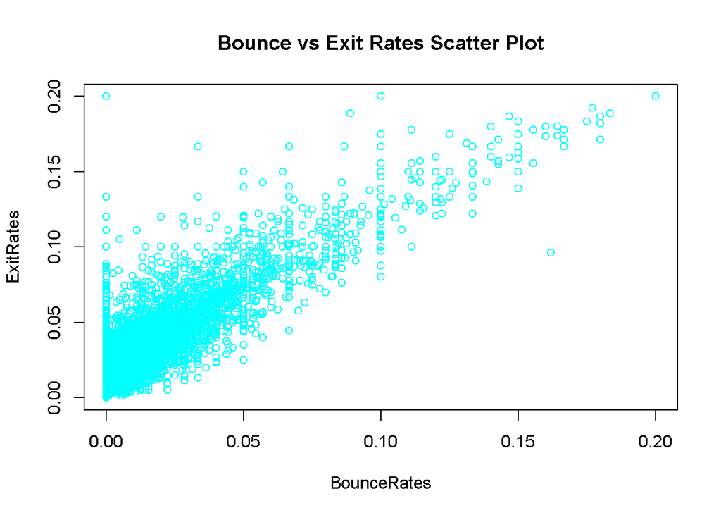

```r
plot(ExitRates ~ BounceRates, data = dfclean,
      col = "cyan",
      main = "Bounce vs Exit Rates Scatter Plot")
```

as bounce rates increases so do exit rates which is an indicator of a high positive correlation betwwen bounce rates and exit rates

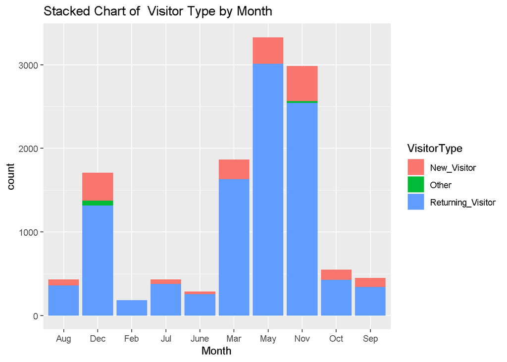

```r
df %>%
    ggplot(aes(Month)) +
    geom_bar(aes(fill = VisitorType))+
    labs(title = "Stacked Chart of  Visitor Type by Month")
```

“Other” customer categories came to shop on November and December. i would recommend to the company investigate who these other customers are. May, Nov, March, and December in that order are the busy months. During these months there is a higher number of new visitors which the company can attract using offers so as to retain them Feb and June are the least busy months. Feb has Valentines day which is a ‘special day’ its expected to be amongest month with highest sale just like may which has mothers day..however this is not the case,i would recommend the company to investigate reasons/factors leading to this anomaly

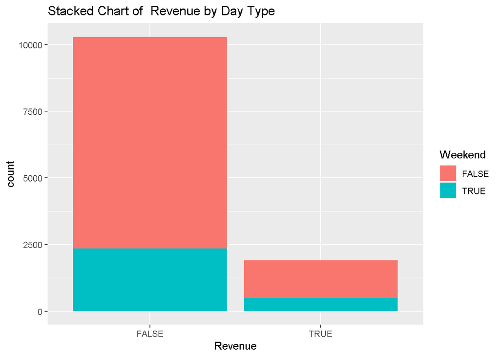

```r
df %>%
    ggplot(aes(Revenue)) +
    geom_bar(aes(fill = Weekend))+
    labs(title = "Stacked Chart of  Revenue by Day Type")
```

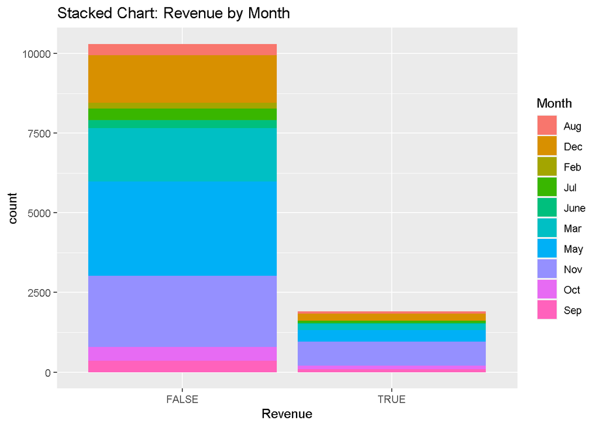

```r
df %>%
    ggplot(aes(Revenue)) +
    geom_bar(aes(fill = Month))+
    labs(title = "Stacked Chart: Revenue by Month")
```

Nov, May and March are best months when the company makes most revenue.

## Multivariate

```r
# Calculate the correlations
corr <- cor(dfclean[,1:10])
corr
```

```
##                         Administrative Administrative_Duration Informational
## Administrative              1.00000000              0.60040965    0.37528761
## Administrative_Duration     0.60040965              1.00000000    0.30143630
## Informational               0.37528761              0.30143630    1.00000000
## Informational_Duration      0.25478602              0.23718986    0.61867795
## ProductRelated              0.42819151              0.28678391    0.37260472
## ProductRelated_Duration     0.37102722              0.35351379    0.38608372
## BounceRates                -0.21366664             -0.13733340   -0.10950530
## ExitRates                  -0.31127413             -0.20202445   -0.15956681
## PageValues                  0.09692097              0.06616837    0.04739015
## SpecialDay                 -0.09707210             -0.07473689   -0.04937677
##                         Informational_Duration ProductRelated
## Administrative                      0.25478602     0.42819151
## Administrative_Duration             0.23718986     0.28678391
## Informational                       0.61867795     0.37260472
## Informational_Duration              1.00000000     0.27906195
## ProductRelated                      0.27906195     1.00000000
## ProductRelated_Duration             0.34658069     0.86030819
## BounceRates                        -0.07015947    -0.19351577
## ExitRates                          -0.10293268    -0.28616321
## PageValues                          0.03006416     0.05411549
## SpecialDay                         -0.03129304    -0.02593062
##                         ProductRelated_Duration BounceRates  ExitRates
## Administrative                       0.37102722 -0.21366664 -0.3112741
## Administrative_Duration              0.35351379 -0.13733340 -0.2020245
## Informational                        0.38608372 -0.10950530 -0.1595668
## Informational_Duration               0.34658069 -0.07015947 -0.1029327
## ProductRelated                       0.86030819 -0.19351577 -0.2861632
## ProductRelated_Duration              1.00000000 -0.17437550 -0.2453340
## BounceRates                         -0.17437550  1.00000000  0.9033582
## ExitRates                           -0.24533401  0.90335819  1.0000000
## PageValues                           0.05084062 -0.11599198 -0.1735715
## SpecialDay                          -0.03821065  0.08783999  0.1167838
##                          PageValues  SpecialDay
## Administrative           0.09692097 -0.09707210
## Administrative_Duration  0.06616837 -0.07473689
## Informational            0.04739015 -0.04937677
## Informational_Duration   0.03006416 -0.03129304
## ProductRelated           0.05411549 -0.02593062
## ProductRelated_Duration  0.05084062 -0.03821065
## BounceRates             -0.11599198  0.08783999
## ExitRates               -0.17357154  0.11678376
## PageValues               1.00000000 -0.06453271
## SpecialDay              -0.06453271  1.00000000
```

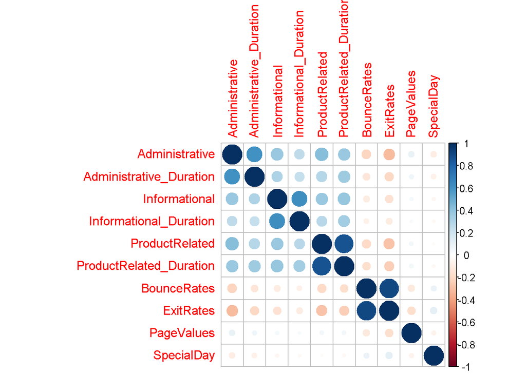

```r
corrplot(corr, method="circle")
```

The deeper the colors(either blue or red) the strong the relationship between the variables. The diagonal are perfectly positively correlated because it shows the correlation of each attribute with itself. there is a strong postive relationship between a page type and its respective duration for example ProductRelated page and Product Related Duration

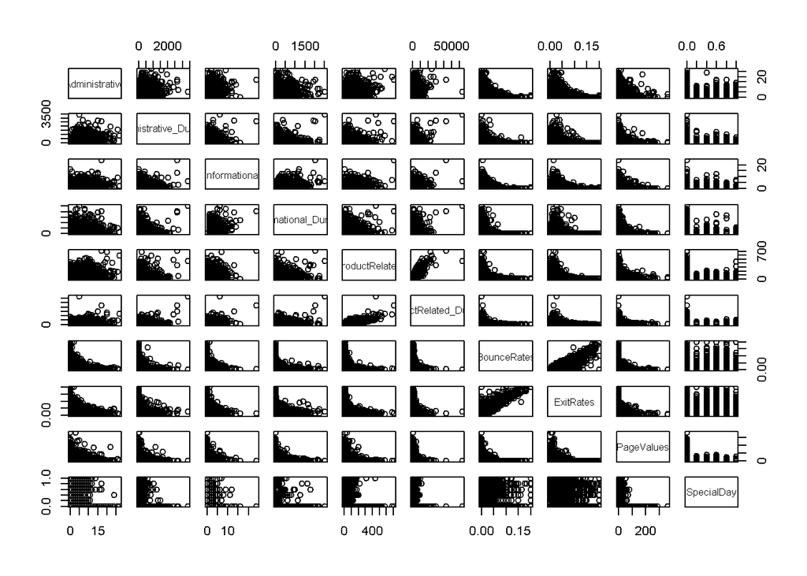

```r
pairs(dfclean[,1:10])
```

#6.Implementing the solution

##6.1 Kmeans clustering

```r
#  One hot encoding of the factor variables.
dfnew<- dfclean[-c(18)]
dfnew
```

```
## # A tibble: 12,199 x 17
##    Administrative Administrative_~ Informational Informational_D~ ProductRelated
##             <dbl>            <dbl>         <dbl>            <dbl>          <dbl>
##  1              0                0             0                0              1
##  2              0                0             0                0              2
##  3              0               -1             0               -1              1
##  4              0                0             0                0              2
##  5              0                0             0                0             10
##  6              0                0             0                0             19
##  7              0               -1             0               -1              1
##  8              1               -1             0               -1              1
##  9              0                0             0                0              2
## 10              0                0             0                0              3
## # ... with 12,189 more rows, and 12 more variables:
## #   ProductRelated_Duration <dbl>, BounceRates <dbl>, ExitRates <dbl>,
## #   PageValues <dbl>, SpecialDay <dbl>, Month <chr>, OperatingSystems <dbl>,
## #   Browser <dbl>, Region <dbl>, TrafficType <dbl>, VisitorType <chr>,
## #   Weekend <lgl>
```

```r
dummy = dummyVars(" ~ .", data = dfnew)

dfcleanfinal = data.frame(predict(dummy, newdata = dfnew))
dfcleanfinal
```

```
##      Administrative Administrative_Duration Informational
## 1                 0                0.000000             0
## 2                 0                0.000000             0
## 3                 0               -1.000000             0
## 4                 0                0.000000             0
## 5                 0                0.000000             0
## 6                 0                0.000000             0
## 7                 0               -1.000000             0
## 8                 1               -1.000000             0
## 9                 0                0.000000             0
## 10                0                0.000000             0
## 11                0                0.000000             0
## 12                0                0.000000             0
## 13                0                0.000000             0
## 14                0                0.000000             0
```

[output cut: 20680 more lines]

```r
glimpse(dfcleanfinal)
```

```
## Rows: 12,199
## Columns: 29
## $ Administrative               <dbl> 0, 0, 0, 0, 0, 0, 0, 1, 0, 0, 0, 0, 0,...
## $ Administrative_Duration      <dbl> 0, 0, -1, 0, 0, 0, -1, -1, 0, 0, 0, 0,...
## $ Informational                <dbl> 0, 0, 0, 0, 0, 0, 0, 0, 0, 0, 0, 0, 0,...
## $ Informational_Duration       <dbl> 0, 0, -1, 0, 0, 0, -1, -1, 0, 0, 0, 0,...
## $ ProductRelated               <dbl> 1, 2, 1, 2, 10, 19, 1, 1, 2, 3, 3, 16,...
## $ ProductRelated_Duration      <dbl> 0.000000, 64.000000, -1.000000, 2.6666...
## $ BounceRates                  <dbl> 0.200000000, 0.000000000, 0.200000000,...
## $ ExitRates                    <dbl> 0.200000000, 0.100000000, 0.200000000,...
## $ PageValues                   <dbl> 0, 0, 0, 0, 0, 0, 0, 0, 0, 0, 0, 0, 0,...
## $ SpecialDay                   <dbl> 0.0, 0.0, 0.0, 0.0, 0.0, 0.0, 0.4, 0.0...
## $ MonthAug                     <dbl> 0, 0, 0, 0, 0, 0, 0, 0, 0, 0, 0, 0, 0,...
## $ MonthDec                     <dbl> 0, 0, 0, 0, 0, 0, 0, 0, 0, 0, 0, 0, 0,...
## $ MonthFeb                     <dbl> 1, 1, 1, 1, 1, 1, 1, 1, 1, 1, 1, 1, 1,...
```

[output cut: 16 more lines]

```r
# Since clustering is a type of Unsupervised Learning,

# We will, therefore, remove Class Attribute “Revenue” and store it in another variable.

dfcleanfinal_copy <- dfcleanfinal
dfcleanclass.class<- dfclean[, "Revenue"]

dfcleanfinal_copy1 <- dfcleanfinal
```

```r
# Previewing the class
head(dfcleanclass.class)
```

```
## # A tibble: 6 x 1
##   Revenue
##   <lgl>
## 1 FALSE
## 2 FALSE
## 3 FALSE
## 4 FALSE
## 5 FALSE
## 6 FALSE
```

```r
# Previewing the dataset with dummy variables without the target variable
head(dfcleanfinal_copy)
```

```
##   Administrative Administrative_Duration Informational Informational_Duration
## 1              0                       0             0                      0
## 2              0                       0             0                      0
## 3              0                      -1             0                     -1
## 4              0                       0             0                      0
## 5              0                       0             0                      0
## 6              0                       0             0                      0
##   ProductRelated ProductRelated_Duration BounceRates ExitRates PageValues
## 1              1                0.000000  0.20000000 0.2000000          0
## 2              2               64.000000  0.00000000 0.1000000          0
## 3              1               -1.000000  0.20000000 0.2000000          0
## 4              2                2.666667  0.05000000 0.1400000          0
## 5             10              627.500000  0.02000000 0.0500000          0
## 6             19              154.216667  0.01578947 0.0245614          0
##   SpecialDay MonthAug MonthDec MonthFeb MonthJul MonthJune MonthMar MonthMay
```

[output cut: 27 more lines]

```r
#  : Normalizing OR SCALING the data will do boththem select thebest
# This is important to ensure that no particular attribute,
# Has more impact on clustering algorithm than others
```

```r
dfnormalized <- as.data.frame(apply(dfcleanfinal_copy1, 2, function(x) (x - min(x))/(max(x)-min(x))))
```

```r
summary(dfnormalized)
```

```
##  Administrative    Administrative_Duration Informational
##  Min.   :0.00000   Min.   :0.0000000       Min.   :0.0000
##  1st Qu.:0.00000   1st Qu.:0.0002941       1st Qu.:0.0000
##  Median :0.03704   Median :0.0029414       Median :0.0000
##  Mean   :0.08667   Mean   :0.0243201       Mean   :0.0212
##  3rd Qu.:0.14815   3rd Qu.:0.0281638       3rd Qu.:0.0000
##  Max.   :1.00000   Max.   :1.0000000       Max.   :1.0000
##  Informational_Duration ProductRelated    ProductRelated_Duration
##  Min.   :0.0000000      Min.   :0.00000   Min.   :0.000000
##  1st Qu.:0.0003921      1st Qu.:0.01135   1st Qu.:0.003042
##  Median :0.0003921      Median :0.02553   Median :0.009543
##  Mean   :0.0140518      Mean   :0.04547   Mean   :0.018891
##  3rd Qu.:0.0003921      3rd Qu.:0.05390   3rd Qu.:0.023112
##  Max.   :1.0000000      Max.   :1.00000   Max.   :1.000000
##   BounceRates        ExitRates         PageValues        SpecialDay
##  Min.   :0.00000   Min.   :0.00000   Min.   :0.00000   Min.   :0.00000
##  1st Qu.:0.00000   1st Qu.:0.07111   1st Qu.:0.00000   1st Qu.:0.00000
##  Median :0.01465   Median :0.12500   Median :0.00000   Median :0.00000
##  Mean   :0.10223   Mean   :0.20748   Mean   :0.01645   Mean   :0.06197
##  3rd Qu.:0.08333   3rd Qu.:0.24242   3rd Qu.:0.00000   3rd Qu.:0.00000
##  Max.   :1.00000   Max.   :1.00000   Max.   :1.00000   Max.   :1.00000
##     MonthAug          MonthDec         MonthFeb          MonthJul
##  Min.   :0.00000   Min.   :0.0000   Min.   :0.00000   Min.   :0.00000
##  1st Qu.:0.00000   1st Qu.:0.0000   1st Qu.:0.00000   1st Qu.:0.00000
##  Median :0.00000   Median :0.0000   Median :0.00000   Median :0.00000
##  Mean   :0.03549   Mean   :0.1398   Mean   :0.01492   Mean   :0.03541
##  3rd Qu.:0.00000   3rd Qu.:0.0000   3rd Qu.:0.00000   3rd Qu.:0.00000
##  Max.   :1.00000   Max.   :1.0000   Max.   :1.00000   Max.   :1.00000
##    MonthJune          MonthMar         MonthMay         MonthNov
##  Min.   :0.00000   Min.   :0.0000   Min.   :0.0000   Min.   :0.0000
##  1st Qu.:0.00000   1st Qu.:0.0000   1st Qu.:0.0000   1st Qu.:0.0000
##  Median :0.00000   Median :0.0000   Median :0.0000   Median :0.0000
##  Mean   :0.02336   Mean   :0.1519   Mean   :0.2728   Mean   :0.2445
##  3rd Qu.:0.00000   3rd Qu.:0.0000   3rd Qu.:1.0000   3rd Qu.:0.0000
##  Max.   :1.00000   Max.   :1.0000   Max.   :1.0000   Max.   :1.0000
##     MonthOct        MonthSep       OperatingSystems    Browser
##  Min.   :0.000   Min.   :0.00000   Min.   :0.0000   Min.   :0.00000
##  1st Qu.:0.000   1st Qu.:0.00000   1st Qu.:0.1429   1st Qu.:0.08333
##  Median :0.000   Median :0.00000   Median :0.1429   Median :0.08333
##  Mean   :0.045   Mean   :0.03672   Mean   :0.1606   Mean   :0.11318
##  3rd Qu.:0.000   3rd Qu.:0.00000   3rd Qu.:0.2857   3rd Qu.:0.08333
##  Max.   :1.000   Max.   :1.00000   Max.   :1.0000   Max.   :1.00000
##      Region        TrafficType      VisitorTypeNew_Visitor VisitorTypeOther
##  Min.   :0.0000   Min.   :0.00000   Min.   :0.0000         Min.   :0.00000
##  1st Qu.:0.0000   1st Qu.:0.05263   1st Qu.:0.0000         1st Qu.:0.00000
##  Median :0.2500   Median :0.05263   Median :0.0000         Median :0.00000
##  Mean   :0.2692   Mean   :0.16182   Mean   :0.1388         Mean   :0.00664
##  3rd Qu.:0.3750   3rd Qu.:0.15789   3rd Qu.:0.0000         3rd Qu.:0.00000
##  Max.   :1.0000   Max.   :1.00000   Max.   :1.0000         Max.   :1.00000
##  VisitorTypeReturning_Visitor  WeekendFALSE     WeekendTRUE
##  Min.   :0.0000               Min.   :0.0000   Min.   :0.0000
##  1st Qu.:1.0000               1st Qu.:1.0000   1st Qu.:0.0000
##  Median :1.0000               Median :1.0000   Median :0.0000
##  Mean   :0.8546               Mean   :0.7659   Mean   :0.2341
##  3rd Qu.:1.0000               3rd Qu.:1.0000   3rd Qu.:0.0000
##  Max.   :1.0000               Max.   :1.0000   Max.   :1.0000
```

```r
head(dfnormalized)
```

```
##   Administrative Administrative_Duration Informational Informational_Duration
## 1              0            0.0002941393             0           0.0003920992
## 2              0            0.0002941393             0           0.0003920992
## 3              0            0.0000000000             0           0.0000000000
## 4              0            0.0002941393             0           0.0003920992
## 5              0            0.0002941393             0           0.0003920992
## 6              0            0.0002941393             0           0.0003920992
##   ProductRelated ProductRelated_Duration BounceRates ExitRates PageValues
## 1    0.001418440            1.563122e-05  1.00000000  1.000000          0
## 2    0.002836879            1.016029e-03  0.00000000  0.500000          0
## 3    0.001418440            0.000000e+00  1.00000000  1.000000          0
## 4    0.002836879            5.731448e-05  0.25000000  0.700000          0
## 5    0.014184397            9.824223e-03  0.10000000  0.250000          0
## 6    0.026950355            2.426226e-03  0.07894737  0.122807          0
##   SpecialDay MonthAug MonthDec MonthFeb MonthJul MonthJune MonthMar MonthMay
```

[output cut: 27 more lines]

```r
dfscaled <- scale(dfcleanfinal_copy1)
```

```r
head(dfscaled)
```

```
##   Administrative Administrative_Duration Informational Informational_Duration
## 1     -0.7025315              -0.4601081    -0.3988128             -0.2462725
## 2     -0.7025315              -0.4601081    -0.3988128             -0.2462725
## 3     -0.7025315              -0.4657410    -0.3988128             -0.2533417
## 4     -0.7025315              -0.4601081    -0.3988128             -0.2462725
## 5     -0.7025315              -0.4601081    -0.3988128             -0.2462725
## 6     -0.7025315              -0.4601081    -0.3988128             -0.2462725
##   ProductRelated ProductRelated_Duration  BounceRates  ExitRates PageValues
## 1     -0.6963635              -0.6289343  3.954699721  3.4273070 -0.3190356
## 2     -0.6739424              -0.5955997 -0.450343788  1.2650121 -0.3190356
## 3     -0.6963635              -0.6294551  3.954699721  3.4273070 -0.3190356
## 4     -0.6739424              -0.6275453  0.650917089  2.1299300 -0.3190356
## 5     -0.4945739              -0.3020990 -0.009839437  0.1838646 -0.3190356
## 6     -0.2927843              -0.5486101 -0.102577188 -0.3661929 -0.3190356
##   SpecialDay   MonthAug   MonthDec MonthFeb   MonthJul  MonthJune   MonthMar
```

[output cut: 27 more lines]

It is evident that there are some attributes still with large values compared to others when scaling is done Normalizing has yielded better results

```r
install.packages("NbClust")
library(cluster)

library(NbClust)
```

```r
# Applying the K-means clustering algorithm with no. of centroids(k)=4

result<- kmeans(dfnormalized,4)
```

```r
result
```

```
## K-means clustering with 4 clusters of sizes 2380, 1278, 2856, 5685
##
## Cluster means:
##   Administrative Administrative_Duration Informational Informational_Duration
## 1     0.06761594              0.01926421    0.01682423            0.010404632
## 2     0.09314322              0.02706681    0.01356286            0.007790822
## 3     0.09203496              0.02558730    0.02449521            0.016384511
## 4     0.09049155              0.02518258    0.02309440            0.015814238
##   ProductRelated ProductRelated_Duration BounceRates ExitRates PageValues
## 1     0.03781274              0.01548144  0.14193483 0.2589451 0.01183969
## 2     0.02550861              0.01007757  0.02811417 0.1088582 0.03318895
## 3     0.04704343              0.01916769  0.08728349 0.1847150 0.01747125
## 4     0.05237897              0.02215951  0.10978578 0.2195497 0.01411290
##   SpecialDay   MonthAug  MonthDec     MonthFeb   MonthJul  MonthJune  MonthMar
## 1 0.22596639 0.00000000 0.0000000 0.0000000000 0.00000000 0.00000000 0.0000000
```

[output cut: 1907 more lines]

```r
# Previewing the no. of records in each cluster
#
result$size
```

```
## [1] 2380 1278 2856 5685
```

```r
# Getting the value of cluster center
# ---
#
result$centers
```

```
##   Administrative Administrative_Duration Informational Informational_Duration
## 1     0.06761594              0.01926421    0.01682423            0.010404632
## 2     0.09314322              0.02706681    0.01356286            0.007790822
## 3     0.09203496              0.02558730    0.02449521            0.016384511
## 4     0.09049155              0.02518258    0.02309440            0.015814238
##   ProductRelated ProductRelated_Duration BounceRates ExitRates PageValues
## 1     0.03781274              0.01548144  0.14193483 0.2589451 0.01183969
## 2     0.02550861              0.01007757  0.02811417 0.1088582 0.03318895
## 3     0.04704343              0.01916769  0.08728349 0.1847150 0.01747125
## 4     0.05237897              0.02215951  0.10978578 0.2195497 0.01411290
##   SpecialDay   MonthAug  MonthDec     MonthFeb   MonthJul  MonthJune  MonthMar
## 1 0.22596639 0.00000000 0.0000000 0.0000000000 0.00000000 0.00000000 0.0000000
## 2 0.02050078 0.03755869 0.2456964 0.0007824726 0.03208138 0.01956182 0.1103286
## 3 0.05560224 0.03361345 0.1264006 0.0098039216 0.03641457 0.01645658 0.1663165
## 4 0.00583993 0.05083553 0.1813544 0.0269129288 0.05048373 0.03746702 0.2175901
##    MonthMay  MonthNov   MonthOct   MonthSep OperatingSystems   Browser
## 1 1.0000000 0.0000000 0.00000000 0.00000000        0.1640456 0.1169468
## 2 0.1830986 0.2378717 0.06572770 0.06729264        0.1739325 0.1416275
## 3 0.2500000 0.2769608 0.05042017 0.03361345        0.1610644 0.1029704
## 4 0.0000000 0.3321020 0.05646438 0.04678980        0.1559744 0.1103342
##      Region TrafficType VisitorTypeNew_Visitor VisitorTypeOther
## 1 0.2625000   0.1896727              0.0000000      0.000000000
## 2 0.3095657   0.1798040              0.9499218      0.050078247
## 3 0.2682511   0.1608801              0.1677171      0.002450980
## 4 0.2633245   0.1465908              0.0000000      0.001759015
##   VisitorTypeReturning_Visitor WeekendFALSE WeekendTRUE
## 1                    1.0000000            1           0
## 2                    0.0000000            1           0
## 3                    0.8298319            0           1
## 4                    0.9982410            1           0
```

```r
# Getting the cluster vector that shows the cluster where each record falls
# ---
#
result$cluster
```

[output not shown]

[output cut: 1863 more lines]

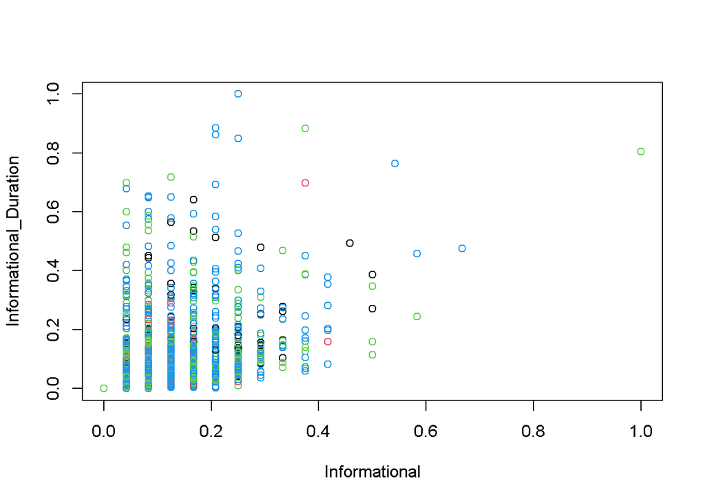

```r
# Plotting to see how  3 and 4th variables data points have been distributed in clusters
plot(dfnormalized[c(3,4)], col = result$cluster)
```

```r
#In order to improve this accuracy further, we may try different values of “k”.
dfnormalizeda <- kmeans(dfnormalized, centers = 2, nstart = 25)
dfnormalizedb <- kmeans(dfnormalized, centers = 3, nstart = 25)
dfnormalizedc <- kmeans(dfnormalized, centers = 4, nstart = 25)
```

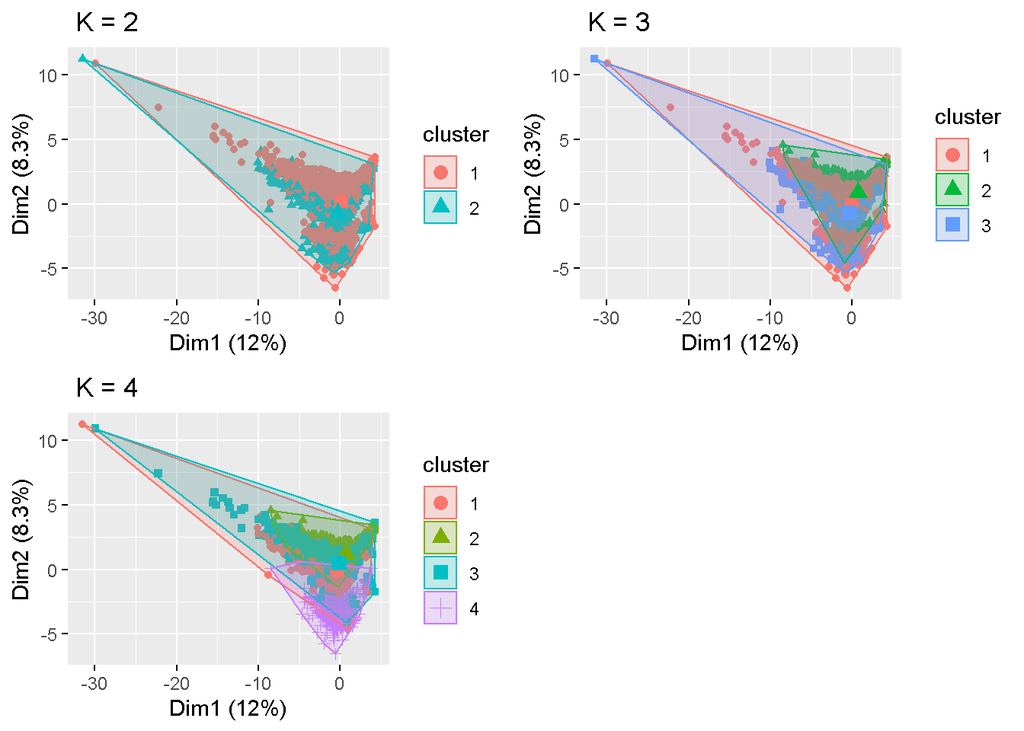

```r
p1 <- fviz_cluster(dfnormalizeda, geom = "point", data = dfnormalized) + ggtitle(" K = 2")
p2 <- fviz_cluster(dfnormalizedb, geom = "point", data = dfnormalized) + ggtitle(" K = 3")
p3 <- fviz_cluster(dfnormalizedc, geom = "point", data = dfnormalized) + ggtitle(" K = 4")
install.packages("gridExtra")
library(gridExtra)
grid.arrange(p1, p2, p3, nrow = 2)
```

K4 has better separation of the clusters compared to the others